# Elasticity Analysis for *Acropora palmata*

Understanding Which Vital Rates Drive Population Growth

Detmer & Stier Lab

January 28, 2026

```r
# Custom theme with colorblind-accessible palettes
colors <- list(
  ocean_deep = "#0a3d62",
  ocean_mid = "#1a5276",
  ocean_light = "#2e86ab",
  coral_warm = "#e07a5f",
  coral_pale = "#f4a261",
  seagrass = "#2a9d8f",
  sand = "#e9c46a"
)

# Semantic colors for vital rate types (colorblind-safe)
vital_rate_colors <- c(
  "Stasis" = "#3B528B",       # Mako blue - stability/persistence

  "Growth" = "#21918C",       # Teal - positive development
  "Fragmentation" = "#5DC863",# Green - reproduction/new life
  "Shrinkage" = "#FDE725"     # Yellow - caution/regression
)

theme_coral <- theme_minimal(base_size = 12) +
  theme(
    plot.title = element_text(face = "bold", size = 14, color = "#2C3E50"),
    plot.subtitle = element_text(color = "#7F8C8D", size = 11),
    plot.caption = element_text(color = "#95A5A6", size = 9, hjust = 0),
    panel.grid.minor = element_blank(),
    legend.position = "bottom"
  )
theme_set(theme_coral)

# Helper functions
fmt_pct <- function(x, digits = 1) paste0(round(x * 100, digits), "%")

#' Calculate text color for contrast against background
#' Uses relative luminance formula (WCAG)
get_text_color <- function(hex_color) {
  # Convert hex to RGB
  rgb_vals <- col2rgb(hex_color) / 255
  # Calculate relative luminance
  luminance <- 0.2126 * rgb_vals[1,] + 0.7152 * rgb_vals[2,] + 0.0722 * rgb_vals[3,]
  # Return white for dark backgrounds, dark gray for light backgrounds
  ifelse(luminance < 0.5, "white", "#2C3E50")
}
```

Estimated reading time: 15 minutes | Skip to Key Finding | Skip to Recommendations

**Jump to:** Summary Key Finding Recommendations Technical Details

# Executive Summary

### 0.0.1 Bottom Line for Practitioners

**Protecting existing large adult colonies (>2,000 cm²) is the single most effective conservation strategy.**

[output not shown]

# 1 Introduction

## 1.1 What is Elasticity Analysis?

**Elasticity analysis** is a core tool in population ecology that answers a critical question: *Which vital rates (survival, growth, reproduction) have the most influence on population growth?*

For conservation and restoration planning, this tells us where to focus limited resources. If improving adult survival has 10× more impact on population growth than improving juvenile growth, we should prioritize protecting adults.

### 1.1.1 Key Concepts

| Term | Definition | Why It Matters |
| --- | --- | --- |
| **λ (lambda)** | Population growth rate | λ < 1 means declining; λ > 1 means growing |
| **Sensitivity** | How much λ changes per unit change in a vital rate | Tells us which rates matter most (in absolute terms) |
| **Elasticity** | Proportional sensitivity (% change in λ per % change in rate) | Allows fair comparison across rates with different scales |

Elasticities always sum to 1, making them directly comparable. A vital rate with elasticity 0.50 means a 1% improvement in that rate produces a 0.50% improvement in λ.

## 1.2 Why Elasticity Matters for *A. palmata*

Elkhorn coral populations face multiple threats. Elasticity analysis helps us answer:

1. **Should we focus on protecting large adults or outplanting juveniles?**
2. **How much does improving nursery survival help vs. reducing adult mortality?**
3. **What’s the minimum improvement needed to stabilize the population?**

# 2 Loading the Data

First, let’s load the pre-computed results from the transition matrix analysis.

```r
# Load pre-computed results
results <- readRDS(file.path(output_dir, "transition_matrix.rds"))

# Extract key matrices
A <- results$projection_matrix           # Projection matrix
S <- results$survival_rates              # Survival by size class
G <- results$growth_transitions          # Growth transition probabilities
elasticity <- results$elasticity         # Elasticity matrix
sensitivity <- results$sensitivity       # Sensitivity matrix
lambda <- results$lambda                 # Population growth rate
lambda_ci <- results$lambda_ci           # Bootstrap confidence interval
w <- results$stable_distribution         # Stable size distribution
v <- results$reproductive_values         # Reproductive values

# Size class definitions
size_labels <- results$size_class_labels
size_breaks <- results$size_class_breaks
```

```r
cat(sprintf("Population growth rate (λ): %.4f\n", lambda))
```

```
## Population growth rate (λ): 0.9661
```

```r
cat(sprintf("95%% Confidence Interval: [%.3f, %.3f]\n", lambda_ci[1], lambda_ci[2]))
```

```
## 95% Confidence Interval: [0.722, 0.985]
```

```r
cat(sprintf("Interpretation: Population is %s at %.1f%% per year\n",
            ifelse(lambda < 1, "DECLINING", "GROWING"),
            abs(lambda - 1) * 100))
```

```
## Interpretation: Population is DECLINING at 3.4% per year
```

# 3 The Projection Matrix

## 3.1 Understanding the Matrix Structure

A **Lefkovitch matrix** (size-structured projection matrix) describes how individuals transition between size classes over one time step (typically one year).

$$\mathbf{A} = \begin{bmatrix}
a_{11} & a_{12} & \cdots & a_{15} \\
a_{21} & a_{22} & \cdots & a_{25} \\
\vdots & \vdots & \ddots & \vdots \\
a_{51} & a_{52} & \cdots & a_{55}
\end{bmatrix}$$

Where $a_{ij}$ = probability of transitioning FROM class $j$ TO class $i$ (including survival).

- **Diagonal elements** ($a_{ii}$): Probability of staying in the same size class (stasis)
- **Subdiagonal elements**: Probability of growing to a larger class
- **Superdiagonal elements**: Probability of shrinking to a smaller class
- **Top row**: Contribution from reproduction/fragmentation

```r
# Display the projection matrix
A_df <- as.data.frame(round(A, 4))
colnames(A_df) <- c("SC1", "SC2", "SC3", "SC4", "SC5")
rownames(A_df) <- c("→ SC1", "→ SC2", "→ SC3", "→ SC4", "→ SC5")

kable(A_df, caption = "Projection Matrix (A) - Columns = FROM, Rows = TO") %>%
  kable_styling(bootstrap_options = c("striped", "hover")) %>%
  column_spec(1, bold = TRUE) %>%
  add_header_above(c(" " = 1, "From Size Class" = 5))
```

Projection Matrix (A) - Columns = FROM, Rows = TO

|  | From Size Class SC1 | From Size Class SC2 | From Size Class SC3 | From Size Class SC4 | From Size Class SC5 |
| --- | --- | --- | --- | --- | --- |
| → SC1 | 0.2458 | 0.0634 | 0.0990 | 0.1002 | 0.0534 |
| → SC2 | 0.3598 | 0.2956 | 0.0474 | 0.0455 | 0.1984 |
| → SC3 | 0.1073 | 0.2821 | 0.4929 | 0.0994 | 0.2947 |
| → SC4 | 0.0112 | 0.0013 | 0.1292 | 0.5750 | 0.0921 |
| → SC5 | 0.0000 | 0.0013 | 0.0000 | 0.1557 | 0.8634 |

## 3.2 Visualizing the Matrix

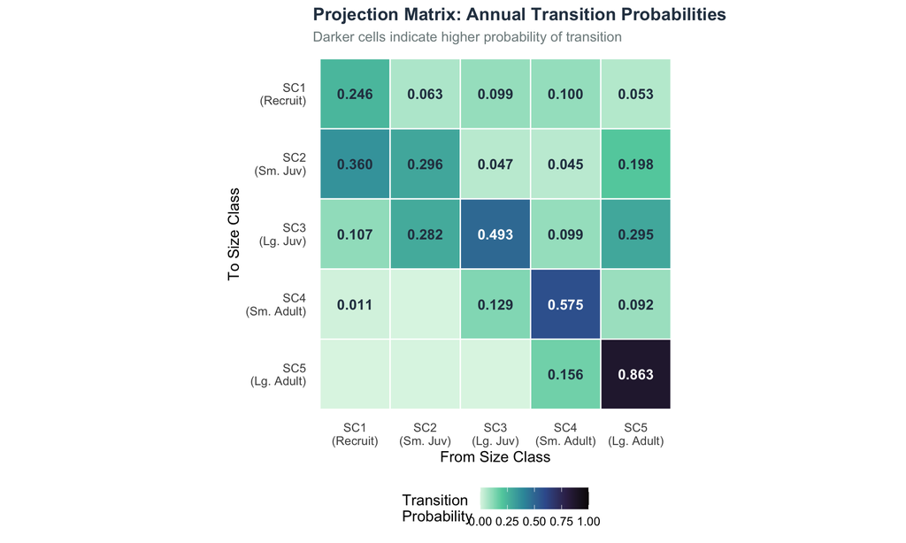

```r
# Prepare data for plotting with conditional text colors
A_plot <- as.data.frame(as.table(A)) %>%
  rename(to = Var1, from = Var2, probability = Freq) %>%
  mutate(
    to = factor(to, levels = rev(size_labels)),
    from = factor(from, levels = size_labels),
    label = ifelse(probability > 0.005, sprintf("%.3f", probability), "")
  )

# Get mako colors for text contrast calculation
n_colors <- 100
mako_palette <- viridis::mako(n_colors, direction = -1)
A_plot <- A_plot %>%
  mutate(
    # Map probability to color index (1-100)
    color_idx = pmax(1, pmin(n_colors, ceiling(probability * n_colors))),
    # Get corresponding hex color
    fill_hex = mako_palette[color_idx],
    # Calculate appropriate text color for contrast
    text_color = get_text_color(fill_hex)
  )

# Heatmap with viridis::mako (colorblind-safe)
ggplot(A_plot, aes(x = from, y = to, fill = probability)) +
  geom_tile(color = "white", linewidth = 0.5) +
  geom_text(aes(label = label, color = text_color), size = 4, fontface = "bold") +
  scale_color_identity() +
  scale_fill_viridis_c(
    option = "mako", direction = -1,
    limits = c(0, 1),
    name = "Transition\nProbability"
  ) +
  scale_x_discrete(labels = c("SC1\n(Recruit)", "SC2\n(Sm. Juv)", "SC3\n(Lg. Juv)",
                              "SC4\n(Sm. Adult)", "SC5\n(Lg. Adult)")) +
  scale_y_discrete(labels = c("SC5\n(Lg. Adult)", "SC4\n(Sm. Adult)", "SC3\n(Lg. Juv)",
                              "SC2\n(Sm. Juv)", "SC1\n(Recruit)")) +
  labs(
    title = "Projection Matrix: Annual Transition Probabilities",
    subtitle = "Darker cells indicate higher probability of transition",
    x = "From Size Class",
    y = "To Size Class"
  ) +
  coord_fixed() +
  theme(panel.grid = element_blank())
```

### 3.2.1 Key Observations from the Matrix

```r
# Extract key probabilities
p_sc5_stasis <- A["SC5_large_adult", "SC5_large_adult"]
p_sc1_growth <- sum(A[2:5, "SC1_recruit"])  # SC1 growing to any larger class
p_sc4_to_sc5 <- A["SC5_large_adult", "SC4_small_adult"]

cat("Key transition probabilities:\n")
```

```
## Key transition probabilities:
```

```r
cat(sprintf("  • Large adult (SC5) staying SC5: %.1f%%\n", p_sc5_stasis * 100))
```

```
##   • Large adult (SC5) staying SC5: 86.3%
```

```r
cat(sprintf("  • Small adult (SC4) growing to SC5: %.1f%%\n", p_sc4_to_sc5 * 100))
```

```
##   • Small adult (SC4) growing to SC5: 15.6%
```

```r
cat(sprintf("  • Recruit (SC1) growing to larger class: %.1f%%\n", p_sc1_growth * 100))
```

```
##   • Recruit (SC1) growing to larger class: 47.8%
```

# 4 Elasticity Analysis

## 4.1 The Mathematical Foundation

### 4.1.1 Sensitivity

Sensitivity measures how much λ changes for a small absolute change in a matrix element:

$$s_{ij} = \frac{\partial \lambda}{\partial a_{ij}} = \frac{v_i \cdot
w_j}{\langle \mathbf{v}, \mathbf{w} \rangle}$$

Where: - $v_i$ = reproductive value of class $i$ (left eigenvector) - $w_j$ = proportion of stable population in class $j$ (right eigenvector)

### 4.1.2 Elasticity

Elasticity is the proportional sensitivity — it tells us the **percent change in λ** for a **percent change in the vital rate**:

$$e_{ij} = \frac{a_{ij}}{\lambda} \cdot s_{ij} = \frac{a_{ij}}{\lambda}
\cdot \frac{\partial \lambda}{\partial a_{ij}}$$

**Critical property**: All elasticities sum to 1. This makes them directly comparable across different vital rates.

## 4.2 Computing Elasticity

Let’s walk through the calculation step by step.

```r
# Step 1: Eigenanalysis of A
eigen_A <- eigen(A)
lambda_calc <- Re(eigen_A$values[1])  # Dominant eigenvalue (= λ)

# Right eigenvector (stable size distribution)
w_calc <- Re(eigen_A$vectors[, 1])
w_calc <- w_calc / sum(w_calc)  # Normalize to proportions

# Left eigenvector (reproductive values)
eigen_At <- eigen(t(A))
v_calc <- Re(eigen_At$vectors[, 1])
v_calc <- v_calc / v_calc[1]  # Scale relative to SC1

# Step 2: Sensitivity matrix
vw_inner <- sum(v_calc * w_calc)  # Inner product <v, w>
sensitivity_calc <- outer(v_calc, w_calc) / vw_inner

# Step 3: Elasticity matrix
elasticity_calc <- (A / lambda_calc) * sensitivity_calc

cat(sprintf("Verification: λ from eigenanalysis = %.6f\n", lambda_calc))
```

```
## Verification: λ from eigenanalysis = 0.966123
```

```r
cat(sprintf("Sum of elasticities = %.4f (should equal 1)\n", sum(elasticity_calc)))
```

```
## Sum of elasticities = 1.0000 (should equal 1)
```

## 4.3 The Elasticity Matrix

```r
# Display elasticity matrix
E_df <- as.data.frame(round(elasticity, 4))
colnames(E_df) <- c("SC1", "SC2", "SC3", "SC4", "SC5")
rownames(E_df) <- c("→ SC1", "→ SC2", "→ SC3", "→ SC4", "→ SC5")

kable(E_df, caption = "Elasticity Matrix - Which transitions matter most?") %>%
  kable_styling(bootstrap_options = c("striped", "hover")) %>%
  column_spec(1, bold = TRUE)
```

Elasticity Matrix - Which transitions matter most?

|  | SC1 | SC2 | SC3 | SC4 | SC5 |
| --- | --- | --- | --- | --- | --- |
| → SC1 | 0.0041 | 0.0017 | 0.0052 | 0.0028 | 0.0023 |
| → SC2 | 0.0066 | 0.0088 | 0.0027 | 0.0014 | 0.0093 |
| → SC3 | 0.0041 | 0.0175 | 0.0590 | 0.0063 | 0.0287 |
| → SC4 | 0.0013 | 0.0003 | 0.0487 | 0.1156 | 0.0283 |
| → SC5 | 0.0000 | 0.0006 | 0.0000 | 0.0681 | 0.5765 |

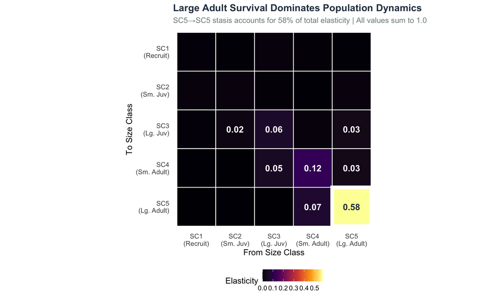

```r
# Visualize elasticity with conditional text colors
E_plot <- as.data.frame(as.table(elasticity)) %>%
  rename(to = Var1, from = Var2, elasticity = Freq) %>%
  mutate(
    to = factor(to, levels = rev(size_labels)),
    from = factor(from, levels = size_labels),
    label = ifelse(elasticity > 0.01, sprintf("%.2f", elasticity), "")
  )

# Calculate text colors for inferno palette
n_colors <- 100
inferno_palette <- viridis::inferno(n_colors, direction = 1)
max_e <- max(E_plot$elasticity)
E_plot <- E_plot %>%
  mutate(
    # Map elasticity to color index
    color_idx = pmax(1, pmin(n_colors, ceiling((elasticity / max_e) * n_colors))),
    fill_hex = inferno_palette[color_idx],
    text_color = get_text_color(fill_hex),
    # Flag the maximum cell for border highlight
    is_max = elasticity == max(elasticity)
  )

# Find the max cell for annotation
max_cell <- E_plot %>% filter(is_max)

ggplot(E_plot, aes(x = from, y = to, fill = elasticity)) +
  geom_tile(color = "white", linewidth = 0.5) +
  # Highlight border on dominant cell
  geom_tile(data = max_cell, aes(x = from, y = to),
            fill = NA, color = "#FFFFFF", linewidth = 2.5) +
  geom_text(aes(label = label, color = text_color), size = 4.5, fontface = "bold") +
  scale_color_identity() +
  scale_fill_viridis_c(
    option = "inferno", direction = 1,
    limits = c(0, max_e),
    name = "Elasticity"
  ) +
  scale_x_discrete(labels = c("SC1\n(Recruit)", "SC2\n(Sm. Juv)", "SC3\n(Lg. Juv)",
                              "SC4\n(Sm. Adult)", "SC5\n(Lg. Adult)")) +
  scale_y_discrete(labels = c("SC5\n(Lg. Adult)", "SC4\n(Sm. Adult)", "SC3\n(Lg. Juv)",
                              "SC2\n(Sm. Juv)", "SC1\n(Recruit)")) +
  labs(
    title = "Large Adult Survival Dominates Population Dynamics",
    subtitle = sprintf("SC5→SC5 stasis accounts for %.0f%% of total elasticity | All values sum to 1.0",
                       max_e * 100),
    x = "From Size Class",
    y = "To Size Class"
  ) +
  coord_fixed() +
  theme(panel.grid = element_blank())
```

# 5 Interpreting Elasticities

## 5.1 Elasticity by Vital Rate Type

We can group elasticities by the type of demographic transition:

```r
# Calculate elasticity sums by type
e_stasis <- sum(diag(elasticity))  # Diagonal = staying same class

e_growth <- sum(elasticity[lower.tri(elasticity)])  # Below diagonal = growing

# Fragmentation (SC4/SC5 producing fragments in SC1-SC3)
e_frag <- sum(elasticity[1:3, 4]) + sum(elasticity[1:4, 5])

# Shrinkage (upper triangle minus fragmentation)
e_shrink <- sum(elasticity[upper.tri(elasticity)]) - e_frag

# Create summary table
elasticity_summary <- data.frame(
  `Vital Rate Type` = c("Stasis (staying same size)",
                        "Growth (moving to larger class)",
                        "Fragmentation (asexual reproduction)",
                        "Shrinkage (moving to smaller class)",
                        "TOTAL"),
  Elasticity = c(e_stasis, e_growth, e_frag, e_shrink,
                 e_stasis + e_growth + e_frag + e_shrink),
  Percent = c(e_stasis, e_growth, e_frag, e_shrink, 1) * 100,
  check.names = FALSE
)

kable(elasticity_summary, digits = c(0, 4, 1),
      caption = "Elasticity Breakdown by Vital Rate Type") %>%
  kable_styling(bootstrap_options = c("striped", "hover")) %>%
  row_spec(5, bold = TRUE, background = "#f0f0f0")
```

Elasticity Breakdown by Vital Rate Type

| Vital Rate Type | Elasticity | Percent |
| --- | --- | --- |
| Stasis (staying same size) | 0.7640 | 76.4 |
| Growth (moving to larger class) | 0.1471 | 14.7 |
| Fragmentation (asexual reproduction) | 0.0792 | 7.9 |
| Shrinkage (moving to smaller class) | 0.0097 | 1.0 |
| TOTAL | 1.0000 | 100.0 |

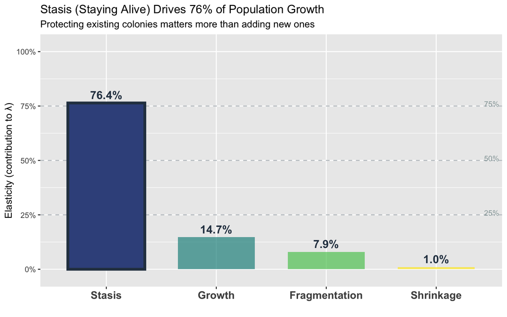

```r
# Visualize breakdown with semantic colors
breakdown_df <- data.frame(
  type = c("Stasis", "Growth", "Fragmentation", "Shrinkage"),
  elasticity = c(e_stasis, e_growth, e_frag, e_shrink)
) %>%
  mutate(
    # Flag the dominant category
    is_dominant = elasticity == max(elasticity),
    # Add alpha for non-dominant bars
    bar_alpha = ifelse(is_dominant, 1.0, 0.7)
  ) %>%
  arrange(desc(elasticity)) %>%
  mutate(cumulative = cumsum(elasticity))

# Dominant value for annotation
stasis_pct <- breakdown_df$elasticity[breakdown_df$type == "Stasis"] * 100
top2_pct <- sum(breakdown_df$elasticity[breakdown_df$type %in% c("Stasis", "Growth")]) * 100

p_bar <- ggplot(breakdown_df, aes(x = reorder(type, -elasticity), y = elasticity, fill = type)) +
  # Reference lines for interpretation
  geom_hline(yintercept = 0.25, linetype = "dashed", color = "#BDC3C7", linewidth = 0.5) +
  geom_hline(yintercept = 0.50, linetype = "dashed", color = "#BDC3C7", linewidth = 0.5) +
  geom_hline(yintercept = 0.75, linetype = "dashed", color = "#BDC3C7", linewidth = 0.5) +
  geom_col(aes(alpha = bar_alpha), width = 0.7) +
  # Add emphasis border on dominant bar
  geom_col(data = filter(breakdown_df, is_dominant),
           width = 0.7, fill = NA, color = "#2C3E50", linewidth = 1.5) +
  geom_text(aes(label = sprintf("%.1f%%", elasticity * 100)),
            vjust = -0.5, size = 4.5, fontface = "bold", color = "#2C3E50") +
  # Annotation for top 2 categories (position with Inf for right side)
  annotate("text", x = Inf, y = 0.26, label = "25%", size = 3, color = "#95A5A6", hjust = 1.2) +
  annotate("text", x = Inf, y = 0.51, label = "50%", size = 3, color = "#95A5A6", hjust = 1.2) +
  annotate("text", x = Inf, y = 0.76, label = "75%", size = 3, color = "#95A5A6", hjust = 1.2) +
  scale_fill_manual(values = vital_rate_colors) +
  scale_alpha_identity() +
  scale_y_continuous(labels = scales::percent, limits = c(0, 1), expand = c(0, 0.08)) +
  labs(
    title = sprintf("Stasis (Staying Alive) Drives %.0f%% of Population Growth", stasis_pct),
    subtitle = "Protecting existing colonies matters more than adding new ones",
    x = "",
    y = "Elasticity (contribution to λ)"
  ) +
  theme(legend.position = "none",
        axis.text.x = element_text(size = 12, face = "bold"))

p_bar
```

## 5.2 Most Important Individual Transitions

```r
# Rank all transitions by elasticity
transitions_df <- as.data.frame(as.table(elasticity)) %>%
  rename(to = Var1, from = Var2, elasticity = Freq) %>%
  filter(elasticity > 0.001) %>%
  arrange(desc(elasticity)) %>%
  mutate(
    transition = paste(from, "→", to),
    percent = elasticity * 100,
    cumulative = cumsum(percent)
  ) %>%
  head(10)

kable(transitions_df %>% select(transition, elasticity, percent, cumulative),
      col.names = c("Transition", "Elasticity", "% of Total", "Cumulative %"),
      digits = c(0, 4, 1, 1),
      caption = "Top 10 Most Important Transitions") %>%
  kable_styling(bootstrap_options = c("striped", "hover")) %>%
  row_spec(1, bold = TRUE, color = "white", background = colors$coral_warm)
```

Top 10 Most Important Transitions

| Transition | Elasticity | % of Total | Cumulative % |
| --- | --- | --- | --- |
| SC5_large_adult → SC5_large_adult | 0.5765 | 57.6 | 57.6 |
| SC4_small_adult → SC4_small_adult | 0.1156 | 11.6 | 69.2 |
| SC4_small_adult → SC5_large_adult | 0.0681 | 6.8 | 76.0 |
| SC3_large_juv → SC3_large_juv | 0.0590 | 5.9 | 81.9 |
| SC3_large_juv → SC4_small_adult | 0.0487 | 4.9 | 86.8 |
| SC5_large_adult → SC3_large_juv | 0.0287 | 2.9 | 89.7 |
| SC5_large_adult → SC4_small_adult | 0.0283 | 2.8 | 92.5 |
| SC2_small_juv → SC3_large_juv | 0.0175 | 1.8 | 94.2 |
| SC5_large_adult → SC2_small_juv | 0.0093 | 0.9 | 95.2 |
| SC2_small_juv → SC2_small_juv | 0.0088 | 0.9 | 96.1 |

### 5.2.1 The Dominant Finding

```r
top_transition <- transitions_df[1, ]

cat('<div class="key-finding-box">\n')
```

```r
cat('<h4>THE DOMINANT FINDING</h4>\n')
```

#### THE DOMINANT FINDING

```r
cat(sprintf('<p style="font-size: 1.25rem; margin-bottom: 0.5rem;">The most important transition is: <strong>%s</strong></p>\n',
            top_transition$transition))
```

The most important transition is: **SC5_large_adult → SC5_large_adult**

```r
cat(sprintf('<p class="finding-value">Elasticity: %.3f (%.1f%% of total)</p>\n',
            top_transition$elasticity, top_transition$percent))
```

Elasticity: 0.576 (57.6% of total)

```r
cat('<hr style="border-color: rgba(255,255,255,0.3); margin: 1rem 0;">\n')
```

```r
cat('<p style="font-size: 1.1rem; line-height: 1.6;">')
```

```r
cat(sprintf('A <strong>1%% improvement</strong> in large adult survival produces a <strong>%.2f%% improvement</strong> in population growth rate. ',
            top_transition$percent))
```

[output not shown]

```r
cat('This means <em>protecting existing large adults</em> is the single most effective conservation strategy.</p>\n')
```

This means *protecting existing large adults* is the single most effective conservation strategy.

```r
cat('</div>\n')
```

# 6 Stable Size Distribution and Reproductive Values

## 6.1 Stable Size Distribution

The **stable size distribution** ($\mathbf{w}$) represents the proportion of individuals in each size class at equilibrium.

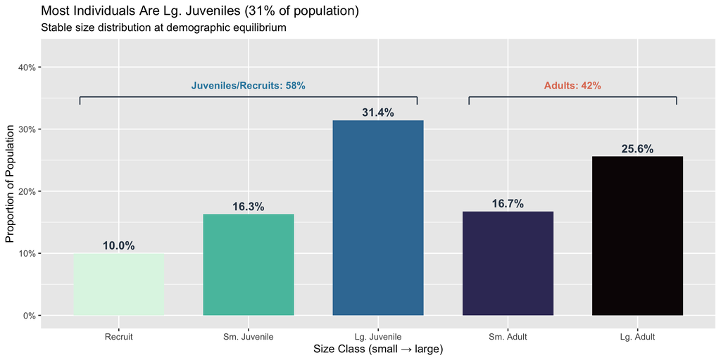

```r
stable_df <- data.frame(
  size_class = factor(size_labels, levels = size_labels),
  proportion = w,
  label = c("Recruit", "Sm. Juvenile", "Lg. Juvenile", "Sm. Adult", "Lg. Adult"),
  # Numeric position for gradient mapping
  class_num = 1:5,
  is_adult = c(FALSE, FALSE, FALSE, TRUE, TRUE)
)

# Find dominant size class for annotation
dominant_class <- stable_df$label[which.max(stable_df$proportion)]
dominant_pct <- max(stable_df$proportion) * 100
adult_pct <- sum(stable_df$proportion[stable_df$is_adult]) * 100
juvenile_pct <- sum(stable_df$proportion[!stable_df$is_adult]) * 100

ggplot(stable_df, aes(x = size_class, y = proportion, fill = class_num)) +
  geom_col(width = 0.7) +
  geom_text(aes(label = sprintf("%.1f%%", proportion * 100)),
            vjust = -0.5, size = 4, fontface = "bold", color = "#2C3E50") +
  # Add bracket annotation for adults
  annotate("segment", x = 3.7, xend = 5.3, y = max(w) * 1.12, yend = max(w) * 1.12,
           color = "#2C3E50", linewidth = 0.5) +
  annotate("segment", x = 3.7, xend = 3.7, y = max(w) * 1.08, yend = max(w) * 1.12,
           color = "#2C3E50", linewidth = 0.5) +
  annotate("segment", x = 5.3, xend = 5.3, y = max(w) * 1.08, yend = max(w) * 1.12,
           color = "#2C3E50", linewidth = 0.5) +
  annotate("text", x = 4.5, y = max(w) * 1.18,
           label = sprintf("Adults: %.0f%%", adult_pct),
           size = 3.5, fontface = "bold", color = "#e07a5f") +
  # Add bracket for juveniles
  annotate("segment", x = 0.7, xend = 3.3, y = max(w) * 1.12, yend = max(w) * 1.12,
           color = "#2C3E50", linewidth = 0.5) +
  annotate("segment", x = 0.7, xend = 0.7, y = max(w) * 1.08, yend = max(w) * 1.12,
           color = "#2C3E50", linewidth = 0.5) +
  annotate("segment", x = 3.3, xend = 3.3, y = max(w) * 1.08, yend = max(w) * 1.12,
           color = "#2C3E50", linewidth = 0.5) +
  annotate("text", x = 2, y = max(w) * 1.18,
           label = sprintf("Juveniles/Recruits: %.0f%%", juvenile_pct),
           size = 3.5, fontface = "bold", color = "#2e86ab") +
  # Single sequential gradient representing size progression
  scale_fill_viridis_c(option = "mako", direction = -1, guide = "none") +
  scale_y_continuous(labels = scales::percent, limits = c(0, max(w) * 1.35)) +
  scale_x_discrete(labels = stable_df$label) +
  labs(
    title = sprintf("Most Individuals Are %ss (%.0f%% of population)", dominant_class, dominant_pct),
    subtitle = "Stable size distribution at demographic equilibrium",
    x = "Size Class (small → large)",
    y = "Proportion of Population"
  ) +
  theme(legend.position = "none")
```

## 6.2 Reproductive Values

**Reproductive value** ($\mathbf{v}$) measures the expected future contribution of an individual in each size class to population growth, relative to a recruit.

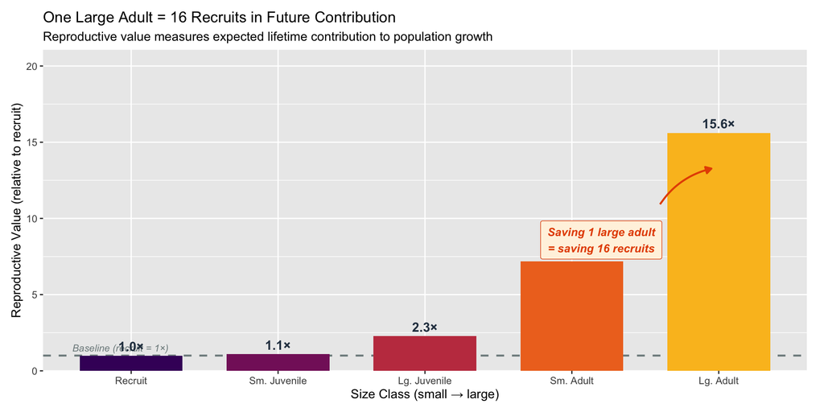

```r
repro_df <- data.frame(
  size_class = factor(size_labels, levels = size_labels),
  value = v,
  label = c("Recruit", "Sm. Juvenile", "Lg. Juvenile", "Sm. Adult", "Lg. Adult"),
  class_num = 1:5
)

# Key values for annotation
sc5_value <- repro_df$value[5]
y_max <- max(repro_df$value) * 1.35

ggplot(repro_df, aes(x = size_class, y = value, fill = class_num)) +
  # Baseline reference line at y = 1 (recruit value)
  geom_hline(yintercept = 1, linetype = "dashed", color = "#7F8C8D", linewidth = 0.8) +
  annotate("text", x = 0.6, y = 1.5, label = "Baseline (recruit = 1×)",
           size = 3, color = "#7F8C8D", fontface = "italic", hjust = 0) +
  geom_col(width = 0.7) +
  geom_text(aes(label = sprintf("%.1f×", value)),
            vjust = -0.5, size = 4, fontface = "bold", color = "#2C3E50") +
  # Callout box for key insight
  annotate("label", x = 4.2, y = sc5_value * 0.55,
           label = sprintf("Saving 1 large adult\n= saving %.0f recruits", sc5_value),
           size = 3.5, fontface = "bold.italic",
           fill = "#FFF3E0", color = "#E65100",
           label.size = 0.5, label.padding = unit(0.5, "lines")) +
  # Curved arrow pointing to SC5 bar
  annotate("curve", x = 4.6, y = sc5_value * 0.7,
           xend = 4.95, yend = sc5_value * 0.85,
           curvature = -0.2, arrow = arrow(length = unit(0.2, "cm"), type = "closed"),
           color = "#E65100", linewidth = 0.8) +
  # Single sequential gradient representing increasing value
  scale_fill_viridis_c(option = "inferno", direction = 1, begin = 0.2, end = 0.85, guide = "none") +
  scale_x_discrete(labels = repro_df$label) +
  scale_y_continuous(limits = c(0, y_max), expand = c(0, 0)) +
  labs(
    title = sprintf("One Large Adult = %.0f Recruits in Future Contribution", sc5_value),
    subtitle = "Reproductive value measures expected lifetime contribution to population growth",
    x = "Size Class (small → large)",
    y = "Reproductive Value (relative to recruit)"
  ) +
  theme(legend.position = "none",
        plot.margin = margin(10, 15, 10, 10))
```

```r
sc5_value <- v[5]
sc4_value <- v[4]

cat(sprintf("A large adult (SC5) has %.1f× the reproductive value of a recruit.\n", sc5_value))
```

```
## A large adult (SC5) has 15.6× the reproductive value of a recruit.
```

```r
cat(sprintf("A small adult (SC4) has %.1f× the reproductive value of a recruit.\n", sc4_value))
```

```
## A small adult (SC4) has 7.2× the reproductive value of a recruit.
```

```r
cat("\nThis means saving ONE large adult is worth as much as saving\n")
```

```
##
## This means saving ONE large adult is worth as much as saving
```

```r
cat(sprintf("%.0f recruits in terms of future population contribution.\n", sc5_value))
```

```
## 16 recruits in terms of future population contribution.
```

# 7 Restoration Implications

## 7.1 What Elasticity Tells Us About Strategy

Based on our elasticity analysis, here’s how different interventions compare:

```r
# Calculate relative importance of different strategies
strategies <- data.frame(
  Strategy = c(
    "Protect large adults from disease/bleaching",
    "Reduce physical damage to colonies",
    "Improve juvenile growth rates",
    "Increase outplanting success",
    "Enhance fragment production"
  ),
  `Target Elasticity` = c(
    elasticity["SC5_large_adult", "SC5_large_adult"],  # SC5 stasis
    elasticity["SC4_small_adult", "SC4_small_adult"] +  # SC4 + SC5 stasis
      elasticity["SC5_large_adult", "SC5_large_adult"],
    e_growth,
    elasticity["SC2_small_juv", "SC1_recruit"] +
      elasticity["SC3_large_juv", "SC1_recruit"],
    e_frag
  ),
  check.names = FALSE
)

strategies <- strategies %>%
  mutate(
    `Relative Impact` = `Target Elasticity` / max(`Target Elasticity`),
    Priority = case_when(
      `Relative Impact` >= 0.8 ~ "HIGH",
      `Relative Impact` >= 0.3 ~ "MEDIUM",
      TRUE ~ "LOW"
    )
  ) %>%
  arrange(desc(`Target Elasticity`))

kable(strategies, digits = c(0, 3, 2, 0),
      caption = "Conservation Strategy Priorities Based on Elasticity") %>%
  kable_styling(bootstrap_options = c("striped", "hover")) %>%
  column_spec(4, bold = TRUE,
              color = ifelse(strategies$Priority == "HIGH", "white", "black"),
              background = ifelse(strategies$Priority == "HIGH", colors$coral_warm,
                          ifelse(strategies$Priority == "MEDIUM", colors$sand, "white")))
```

Conservation Strategy Priorities Based on Elasticity

| Strategy | Target Elasticity | Relative Impact | Priority |
| --- | --- | --- | --- |
| Reduce physical damage to colonies | 0.692 | 1.00 | HIGH |
| Protect large adults from disease/bleaching | 0.576 | 0.83 | HIGH |
| Improve juvenile growth rates | 0.147 | 0.21 | LOW |
| Enhance fragment production | 0.079 | 0.11 | LOW |
| Increase outplanting success | 0.011 | 0.02 | LOW |

## 7.2 Minimum Improvement Needed to Stabilize Population

How much do we need to improve vital rates to achieve λ = 1.0?

```r
# Current deficit
lambda_deficit <- 1 - lambda

# For each vital rate type, calculate required proportional improvement
# Using elasticity: Δλ/λ ≈ e × (Δa/a)
# So: Δa/a = (Δλ/λ) / e

improvement_needed <- data.frame(
  `Vital Rate Type` = c("Large adult survival only",
                        "All stasis rates",
                        "All growth rates",
                        "All rates equally"),
  Elasticity = c(
    elasticity["SC5_large_adult", "SC5_large_adult"],
    e_stasis,
    e_growth,
    1.0
  ),
  check.names = FALSE
)

improvement_needed <- improvement_needed %>%
  mutate(
    `Required Improvement` = (lambda_deficit / lambda) / Elasticity * 100,
    Feasible = ifelse(`Required Improvement` < 20, "Yes", "Challenging")
  )

kable(improvement_needed, digits = c(0, 3, 1, 0),
      caption = sprintf("Improvement Needed to Achieve λ = 1.0 (currently %.3f)", lambda)) %>%
  kable_styling(bootstrap_options = c("striped", "hover"))
```

Improvement Needed to Achieve λ = 1.0 (currently 0.966)

| Vital Rate Type | Elasticity | Required Improvement | Feasible |
| --- | --- | --- | --- |
| Large adult survival only | 0.576 | 6.1 | Yes |
| All stasis rates | 0.764 | 4.6 | Yes |
| All growth rates | 0.147 | 23.8 | Challenging |
| All rates equally | 1.000 | 3.5 | Yes |

# 8 Summary and Conclusions

## 8.1 Key Findings

```r
cat('<div class="alert alert-info">\n')
```

```r
cat('<h4>Summary of Elasticity Analysis</h4>\n')
```

#### Summary of Elasticity Analysis

```r
cat('<ol>\n')
```

```r
cat(sprintf('<li><strong>Stasis dominates</strong>: %.1f%% of elasticity comes from individuals staying in the same size class</li>\n', e_stasis * 100))
```

1. **Stasis dominates**: 76.4% of elasticity comes from individuals staying in the same size class

```r
cat(sprintf('<li><strong>Large adult survival is paramount</strong>: SC5 stasis alone accounts for %.1f%% of total elasticity</li>\n', elasticity["SC5_large_adult", "SC5_large_adult"] * 100))
```

2. **Large adult survival is paramount**: SC5 stasis alone accounts for 57.6% of total elasticity

```r
cat(sprintf('<li><strong>Growth matters, but less</strong>: Growth transitions contribute only %.1f%% to λ</li>\n', e_growth * 100))
```

3. **Growth matters, but less**: Growth transitions contribute only 14.7% to λ

```r
cat(sprintf('<li><strong>Fragmentation is minor</strong>: Asexual reproduction contributes just %.1f%% to population growth</li>\n', e_frag * 100))
```

4. **Fragmentation is minor**: Asexual reproduction contributes just 7.9% to population growth

```r
cat('</ol>\n')
```

```r
cat('</div>\n')
```

## 8.2 Management Recommendations

| Priority | Action | Expected Impact |
| --- | --- | --- |
| **1** | Protect existing large adult colonies (SC5) from disease, bleaching, and physical damage | Highest leverage (~58% of elasticity) |
| **2** | Protect small adult colonies (SC4) | Second highest (~12% of elasticity) |
| **3** | Improve growth conditions to help juveniles reach adult sizes | Moderate impact (~15% of elasticity) |
| **4** | Outplanting/fragmentation programs | Lower direct impact (~8%) but may have indirect benefits |

## 8.3 Caveats

1. **Elasticities are local measures** — they describe sensitivity at current parameter values. Large perturbations may behave differently.
2. **Uncertainty in estimates** — confidence intervals for λ are wide (95% CI: 0.72–0.98), reflecting data limitations.
3. **Study heterogeneity** — most data come from NOAA monitoring in Florida. Results may differ in other regions.
4. **Deterministic model** — does not account for environmental stochasticity, catastrophic events, or density dependence.

# 9 Technical Appendix

## 9.1 Full Elasticity Matrix

```r
kable(round(elasticity, 5), caption = "Complete Elasticity Matrix") %>%
  kable_styling(bootstrap_options = c("striped"))
```

Complete Elasticity Matrix

|  | SC1_recruit | SC2_small_juv | SC3_large_juv | SC4_small_adult | SC5_large_adult |
| --- | --- | --- | --- | --- | --- |
| SC1_recruit | 0.00410 | 0.00173 | 0.00520 | 0.00281 | 0.00228 |
| SC2_small_juv | 0.00660 | 0.00885 | 0.00273 | 0.00140 | 0.00933 |
| SC3_large_juv | 0.00408 | 0.01750 | 0.05902 | 0.00634 | 0.02873 |
| SC4_small_adult | 0.00134 | 0.00026 | 0.04872 | 0.11557 | 0.02828 |
| SC5_large_adult | 0.00000 | 0.00057 | 0.00000 | 0.06805 | 0.57650 |

## 9.2 Sensitivity Matrix

```r
kable(round(sensitivity, 4), caption = "Complete Sensitivity Matrix") %>%
  kable_styling(bootstrap_options = c("striped"))
```

Complete Sensitivity Matrix

|  | SC1_recruit | SC2_small_juv | SC3_large_juv | SC4_small_adult | SC5_large_adult |
| --- | --- | --- | --- | --- | --- |
| SC1_recruit | 0.0161 | 0.0263 | 0.0507 | 0.0270 | 0.0413 |
| SC2_small_juv | 0.0177 | 0.0289 | 0.0558 | 0.0297 | 0.0454 |
| SC3_large_juv | 0.0367 | 0.0599 | 0.1157 | 0.0616 | 0.0942 |
| SC4_small_adult | 0.1157 | 0.1888 | 0.3644 | 0.1942 | 0.2967 |
| SC5_large_adult | 0.2516 | 0.4105 | 0.7923 | 0.4221 | 0.6451 |